# Data Analytics Take Home Examination — CS1: Exploratory & Inferential Analytics of a Fleet Management Operation

# 7. Hypothesis Testing

> **Technique 3 | Chapter 6 — ANOVA, t-test, non-parametric alternatives, effect sizes**

## 7.1 Test 1 — Do Maintenance Costs Differ Across Maintenance Categories?

**H₀:** The mean maintenance cost per event is equal across all maintenance categories. **H₁:** At least one maintenance category has a significantly different mean cost.

**R**

```r
library(car); library(emmeans); library(broom)

# Use top 6 categories by volume for a clean ANOVA
top6 <- c("Routine Maintenance","Mechanical","Engine","Tyre Maintenance",
           "Electrical","Brakes")

anova_data <- maint %>%
  filter(Maint_Cat %in% top6, Amount > 0) %>%
  mutate(log_Amount = log1p(Amount),
         Maint_Cat = factor(Maint_Cat))

# Levene's test (assumption check)
levene_res <- leveneTest(log_Amount ~ Maint_Cat, data = anova_data)
cat("Levene's Test for Homogeneity of Variance:\n")
```

```
Levene's Test for Homogeneity of Variance:
```

```r
print(levene_res)
```

```
Levene's Test for Homogeneity of Variance (center = median)
        Df F value    Pr(>F)
group    5  46.684 < 2.2e-16 ***
      4398
---
Signif. codes:  0 '***' 0.001 '**' 0.01 '*' 0.05 '.' 0.1 ' ' 1
```

```r
# One-way ANOVA on log-transformed amounts
mod_aov <- aov(log_Amount ~ Maint_Cat, data = anova_data)
aov_tidy <- tidy(mod_aov)
cat("\nANOVA Table:\n")
```

```
ANOVA Table:
```

```r
aov_tidy %>%
  mutate(across(where(is.numeric), ~round(., 4))) %>%
  kbl(caption = "One-Way ANOVA: log(Cost) ~ Maintenance Category") %>%
  kable_styling(bootstrap_options = c("striped","hover"), full_width = FALSE) %>%
  row_spec(0, background = "#2c3e50", color = "white") %>%
  row_spec(1, background = "#d5e8f7")
```

One-Way ANOVA: log(Cost) ~ Maintenance Category

| term | df | sumsq | meansq | statistic | p.value |
| --- | --- | --- | --- | --- | --- |
| Maint_Cat | 5 | 471.4323 | 94.2865 | 104.5868 | 0 |
| Residuals | 4398 | 3964.8583 | 0.9015 | NA | NA |

```r
# Effect size: eta-squared
ss_total   <- sum(aov_tidy$sumsq)
eta_sq     <- aov_tidy$sumsq[1] / ss_total
cat(sprintf("\nEta-squared (η²) = %.4f → %.1f%% of variance explained by category\n",
            eta_sq, eta_sq*100))
```

```
Eta-squared (η²) = 0.1063 → 10.6% of variance explained by category
```

```r
# Post-hoc Tukey
cat("\nTukey HSD Post-hoc Pairwise Comparisons:\n")
```

```
Tukey HSD Post-hoc Pairwise Comparisons:
```

```r
em   <- emmeans(mod_aov, ~ Maint_Cat)
cont <- contrast(em, method = "pairwise", adjust = "tukey")
tidy(cont) %>%
  filter(adj.p.value < 0.05) %>%
  arrange(adj.p.value) %>%
  mutate(across(where(is.numeric), ~round(.,4))) %>%
  head(10) %>%
  kbl(caption = "Significant pairwise differences (Tukey HSD, α = 0.05)") %>%
  kable_styling(bootstrap_options = c("striped","hover"), full_width = TRUE) %>%
  row_spec(0, background = "#2c3e50", color = "white")
```

Significant pairwise differences (Tukey HSD, α = 0.05)

| term | contrast | null.value | estimate | std.error | df | statistic | adj.p.value |
| --- | --- | --- | --- | --- | --- | --- | --- |
| Maint_Cat | Brakes - Tyre Maintenance | 0 | 1.1198 | 0.0604 | 4398 | 18.5478 | 0.0000 |
| Maint_Cat | Electrical - Tyre Maintenance | 0 | 0.6901 | 0.0579 | 4398 | 11.9130 | 0.0000 |
| Maint_Cat | Engine - Tyre Maintenance | 0 | 0.9203 | 0.0551 | 4398 | 16.7059 | 0.0000 |
| Maint_Cat | Mechanical - Tyre Maintenance | 0 | 0.9369 | 0.0502 | 4398 | 18.6548 | 0.0000 |
| Maint_Cat | Routine Maintenance - Tyre Maintenance | 0 | 0.8841 | 0.0458 | 4398 | 19.3051 | 0.0000 |
| Maint_Cat | Brakes - Electrical | 0 | 0.4297 | 0.0636 | 4398 | 6.7555 | 0.0000 |
| Maint_Cat | Electrical - Mechanical | 0 | -0.2468 | 0.0541 | 4398 | -4.5650 | 0.0001 |
| Maint_Cat | Brakes - Routine Maintenance | 0 | 0.2357 | 0.0528 | 4398 | 4.4661 | 0.0001 |
| Maint_Cat | Electrical - Engine | 0 | -0.2302 | 0.0586 | 4398 | -3.9275 | 0.0012 |
| Maint_Cat | Electrical - Routine Maintenance | 0 | -0.1939 | 0.0500 | 4398 | -3.8804 | 0.0015 |

**Python**

```python
from scipy.stats import f_oneway, levene as levene_test
from itertools import combinations

top6 = ["Routine Maintenance","Mechanical","Engine","Tyre Maintenance",
        "Electrical","Brakes"]
aov_data = maint[maint["Maint_Cat"].isin(top6) & (maint["Amount"] > 0)].copy()
aov_data["log_Amount"] = np.log1p(aov_data["Amount"])

groups = [grp["log_Amount"].values
          for _, grp in aov_data.groupby("Maint_Cat")]

# Levene's test
stat_lev, p_lev = levene_test(*groups)
print(f"Levene's Test: statistic={stat_lev:.3f}, p={p_lev:.4f}")
```

```
Levene's Test: statistic=46.684, p=0.0000
```

```python
print("→ " + ("Homogeneity assumption met ✅" if p_lev > 0.05
              else "Heterogeneity detected — Welch ANOVA preferred ⚠️"))
```

```
→ Heterogeneity detected — Welch ANOVA preferred ⚠️
```

```python
# One-way ANOVA
F_stat, p_val = f_oneway(*groups)
print(f"\nOne-Way ANOVA: F = {F_stat:.2f}, p = {p_val:.2e}")
```

```
One-Way ANOVA: F = 104.59, p = 1.37e-104
```

```python
print("→ " + ("Reject H₀ ✅ — Categories differ significantly in mean cost"
              if p_val < 0.05 else "Fail to reject H₀"))
```

```
→ Reject H₀ ✅ — Categories differ significantly in mean cost
```

```python
# Eta-squared (manual)
grand_mean = aov_data["log_Amount"].mean()
ss_between = sum(len(g)*(g.mean()-grand_mean)**2 for g in groups)
ss_total_  = sum((aov_data["log_Amount"] - grand_mean)**2)
eta_sq = ss_between / ss_total_
print(f"\nEta-squared (η²) = {eta_sq:.4f} → {eta_sq*100:.1f}% of variance explained")
```

```
Eta-squared (η²) = 0.1063 → 10.6% of variance explained
```

## 7.2 Test 2 — Do Costs Differ Across Vehicle Makes?

**H₀:** Mean maintenance cost per event is equal across all vehicle makes. **H₁:** At least one make has a significantly different mean per-event cost.

**R**

```r
make_data <- maint %>%
  filter(Amount > 0,
         !Make %in% c("THIRD-PARTY VEHICLE")) %>%
  mutate(log_Amount = log1p(Amount),
         Make = factor(Make))

mod_make <- aov(log_Amount ~ Make, data = make_data)
tidy_make <- tidy(mod_make)
tidy_make %>%
  mutate(across(where(is.numeric), ~round(.,4))) %>%
  kbl(caption = "ANOVA: log(Cost) ~ Vehicle Make") %>%
  kable_styling(bootstrap_options = c("striped","hover"), full_width = FALSE) %>%
  row_spec(0, background = "#2c3e50", color = "white")
```

ANOVA: log(Cost) ~ Vehicle Make

| term | df | sumsq | meansq | statistic | p.value |
| --- | --- | --- | --- | --- | --- |
| Make | 7 | 206.9371 | 29.5624 | 21.423 | 0 |
| Residuals | 6850 | 9452.5735 | 1.3799 | NA | NA |

```r
eta_make <- tidy_make$sumsq[1] / sum(tidy_make$sumsq)
cat(sprintf("Eta-squared (η²) = %.4f\n", eta_make))
```

```
Eta-squared (η²) = 0.0214
```

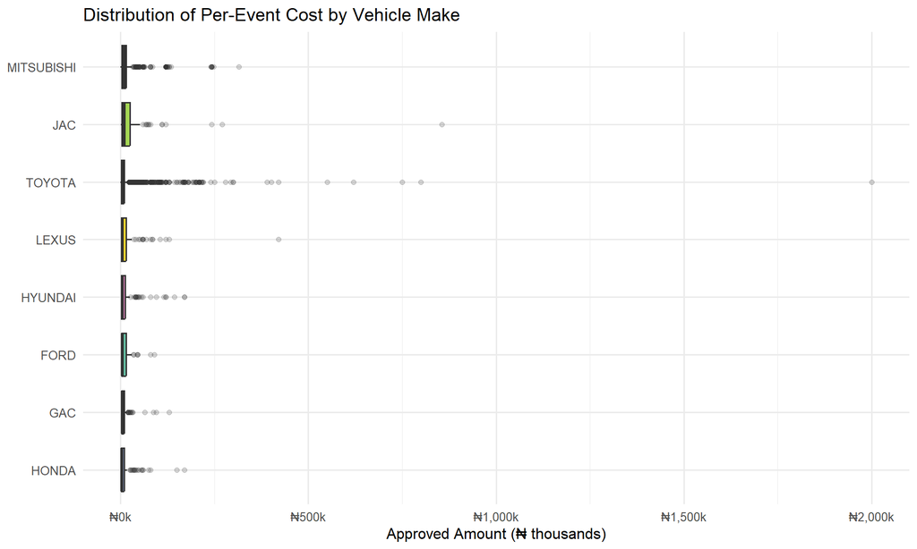

```r
# Boxplot
ggplot(make_data, aes(x = fct_reorder(Make, Amount, median),
                      y = Amount/1e3, fill = Make)) +
  geom_boxplot(outlier.alpha = 0.2, show.legend = FALSE) +
  coord_flip() +
  scale_fill_brewer(palette = "Set2") +
  scale_y_continuous(labels = label_comma(suffix = "k", prefix = "₦")) +
  labs(title = "Distribution of Per-Event Cost by Vehicle Make",
       x = NULL, y = "Approved Amount (₦ thousands)") +
  theme_minimal(base_size = 12)
```

**Python**

```python
make_data = maint[(maint["Amount"] > 0) &
                  (maint["Make"] != "THIRD-PARTY VEHICLE")].copy()
make_data["log_Amount"] = np.log1p(make_data["Amount"])

groups_m = [g["log_Amount"].values for _, g in make_data.groupby("Make")]
F_m, p_m = f_oneway(*groups_m)
print(f"ANOVA by Vehicle Make: F = {F_m:.2f}, p = {p_m:.4f}")
```

```
ANOVA by Vehicle Make: F = 21.42, p = 0.0000
```

```python
print("→ " + ("Reject H₀ ✅ — Vehicle make significantly affects per-event cost"
              if p_m < 0.05 else "Fail to reject H₀"))
```

```
→ Reject H₀ ✅ — Vehicle make significantly affects per-event cost
```

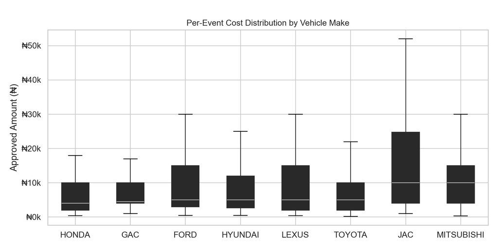

```python
# Boxplot
fig, ax = plt.subplots(figsize=(10, 5))
order = make_data.groupby("Make")["Amount"].median().sort_values().index.tolist()
make_data["Make_ord"] = pd.Categorical(make_data["Make"], categories=order, ordered=True)
make_data.boxplot(column="Amount", by="Make_ord", ax=ax,
                  patch_artist=True, showfliers=False)
ax.set_xlabel("")
ax.set_ylabel("Approved Amount (₦)")
ax.set_title("Per-Event Cost Distribution by Vehicle Make", fontsize=12)
plt.suptitle("")
ax.yaxis.set_major_formatter(mticker.FuncFormatter(lambda x,_: f"₦{x/1e3:.0f}k"))
plt.tight_layout()
plt.savefig("box_make.png", dpi=150, bbox_inches="tight")
plt.show()
```

# 8. Correlation Analysis

> **Technique 4 | Chapter 8 — Pearson, Spearman, Kendall; partial correlation; correlation vs causation**

## 8.1 Full Correlation Matrix

**R**

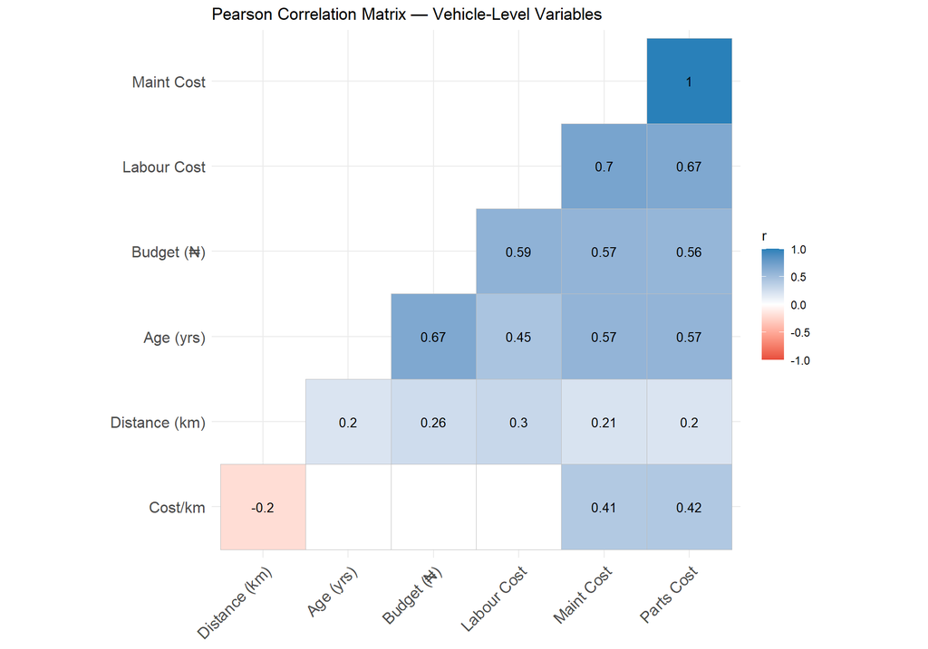

```r
library(ggcorrplot)

corr_vars <- vehicle %>%
  select(Age, Budget, Distance_km, Maint_Cost, Parts_Cost, Labour_Cost, Cost_per_km) %>%
  rename(
    `Age (yrs)`    = Age,
    `Budget (₦)`   = Budget,
    `Distance (km)`= Distance_km,
    `Maint Cost`   = Maint_Cost,
    `Parts Cost`   = Parts_Cost,
    `Labour Cost`  = Labour_Cost,
    `Cost/km`      = Cost_per_km
  )

cor_mat  <- cor(corr_vars, use = "pairwise.complete.obs", method = "pearson")
cor_pval <- cor_pmat(corr_vars)

ggcorrplot(cor_mat,
           hc.order = TRUE,
           type     = "lower",
           lab      = TRUE,
           lab_size = 3.5,
           p.mat    = cor_pval,
           sig.level= 0.05,
           insig    = "blank",
           ggtheme  = theme_minimal(),
           colors   = c("#e74c3c", "white", "#2980b9"),
           title    = "Pearson Correlation Matrix — Vehicle-Level Variables",
           legend.title = "r")
```

**Python**

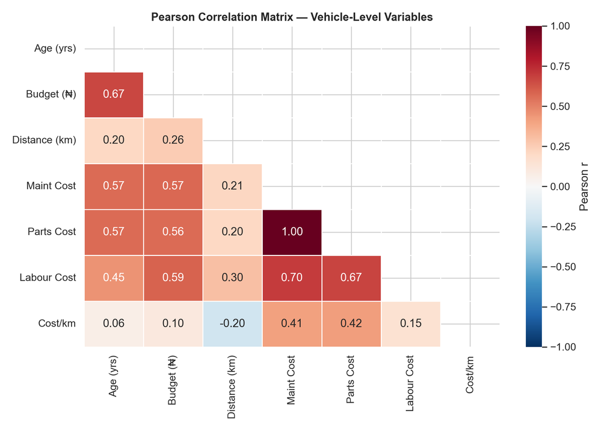

```python
from scipy.stats import pearsonr

corr_cols = ["Age","Budget","Distance_km","Maint_Cost","Parts_Cost","Labour_Cost","Cost_per_km"]
labels    = ["Age (yrs)","Budget (₦)","Distance (km)","Maint Cost","Parts Cost","Labour Cost","Cost/km"]

corr_df = vehicle[corr_cols].rename(columns=dict(zip(corr_cols,labels)))
C = corr_df.corr(method="pearson")

# p-value matrix
p_matrix = pd.DataFrame(np.ones_like(C), index=C.index, columns=C.columns)
for i in C.index:
    for j in C.columns:
        if i != j:
            _, p = pearsonr(corr_df[i].dropna(), corr_df[j].dropna())
            p_matrix.loc[i,j] = p

mask = np.triu(np.ones_like(C, dtype=bool))
fig, ax = plt.subplots(figsize=(10, 7))
sns.heatmap(C, mask=mask, annot=True, fmt=".2f", cmap="RdBu_r",
            vmin=-1, vmax=1, ax=ax, linewidths=0.5,
            cbar_kws={"label":"Pearson r"})
ax.set_title("Pearson Correlation Matrix — Vehicle-Level Variables",
             fontsize=13, fontweight="bold")
plt.tight_layout()
plt.savefig("corrmat.png", dpi=150, bbox_inches="tight")
plt.show()
```

## 8.2 Spearman Correlation (Robustness Check)

**R**

```r
cor_sp <- cor(corr_vars, use="pairwise.complete.obs", method="spearman")
sp_key <- data.frame(
  Pair = c("Age ↔ Maint Cost","Budget ↔ Maint Cost",
           "Distance ↔ Maint Cost","Parts Cost ↔ Maint Cost",
           "Labour Cost ↔ Maint Cost","Age ↔ Budget"),
  Pearson  = c(cor_mat["Maint Cost","Age (yrs)"],
               cor_mat["Maint Cost","Budget (₦)"],
               cor_mat["Maint Cost","Distance (km)"],
               cor_mat["Maint Cost","Parts Cost"],
               cor_mat["Maint Cost","Labour Cost"],
               cor_mat["Budget (₦)","Age (yrs)"]),
  Spearman = c(cor_sp["Maint Cost","Age (yrs)"],
               cor_sp["Maint Cost","Budget (₦)"],
               cor_sp["Maint Cost","Distance (km)"],
               cor_sp["Maint Cost","Parts Cost"],
               cor_sp["Maint Cost","Labour Cost"],
               cor_sp["Budget (₦)","Age (yrs)"])
) %>%
  mutate(across(where(is.numeric), ~round(.,3)),
         Interpretation = case_when(
           abs(Pearson) > 0.7 ~ "🔴 Strong",
           abs(Pearson) > 0.4 ~ "🟠 Moderate",
           TRUE               ~ "🟢 Weak"
         ))

sp_key %>%
  kbl(caption = "Pearson vs Spearman correlation — key pairs") %>%
  kable_styling(bootstrap_options = c("striped","hover"), full_width = TRUE) %>%
  row_spec(0, background = "#2c3e50", color = "white")
```

Pearson vs Spearman correlation — key pairs

| Pair | Pearson | Spearman | Interpretation |
| --- | --- | --- | --- |
| Age ↔︎ Maint Cost | 0.570 | 0.661 | 🟠 Moderate |
| Budget ↔︎ Maint Cost | 0.573 | 0.610 | 🟠 Moderate |
| Distance ↔︎ Maint Cost | 0.211 | 0.335 | 🟢 Weak |
| Parts Cost ↔︎ Maint Cost | 0.999 | 0.999 | 🔴 Strong |
| Labour Cost ↔︎ Maint Cost | 0.700 | 0.775 | 🟠 Moderate |
| Age ↔︎ Budget | 0.665 | 0.582 | 🟠 Moderate |

**Python**

```python
pairs = [("Age","Maint_Cost"),("Budget","Maint_Cost"),
         ("Distance_km","Maint_Cost"),("Parts_Cost","Maint_Cost"),
         ("Labour_Cost","Maint_Cost"),("Age","Budget")]

from scipy.stats import spearmanr
rows = []
for a,b in pairs:
    r_p,_ = pearsonr(vehicle[a], vehicle[b])
    r_s,_ = spearmanr(vehicle[a], vehicle[b])
    rows.append({"Pair":f"{a} ↔ {b}",
                 "Pearson":round(r_p,3),"Spearman":round(r_s,3)})

df_corr = pd.DataFrame(rows)
print(df_corr.to_string(index=False))
```

```
                    Pair  Pearson  Spearman
        Age ↔ Maint_Cost    0.570     0.661
     Budget ↔ Maint_Cost    0.573     0.610
Distance_km ↔ Maint_Cost    0.211     0.335
 Parts_Cost ↔ Maint_Cost    0.999     0.999
Labour_Cost ↔ Maint_Cost    0.700     0.775
            Age ↔ Budget    0.665     0.582
```

**2. Parts Cost ↔︎ Maintenance Cost (r ≈ 1.00):** Near-perfect correlation — unsurprising because parts cost constitutes the overwhelming majority of maintenance expenditure (Labour accounts for only ~10% of approved amounts). This confirms that **parts procurement strategy** (bulk contracts, local sourcing, approved-vendor lists) is the primary lever for cost control.

**3. Budget ↔︎ Maintenance Cost (r = 0.57):** Moderate positive correlation. Higher-budgeted vehicles do tend to cost more to maintain — this partly reflects client contract structures where higher-value vehicles attract larger budgets and more intensive maintenance requirements. Importantly, the correlation is not perfect, suggesting some vehicles significantly overshoot or undershoot their allocated budgets, warranting variance analysis.

**Causation caveat:** All three relationships are correlational. While the age–cost relationship is mechanistically plausible, a controlled experiment (e.g., randomised vehicle retirement) would be needed to establish causation formally.

# 9. Linear Regression

> **Technique 5 | Chapter 9 — OLS regression: coefficients, diagnostics, interpretation**

## 9.1 Model Specification

The regression model predicts **log-transformed total vehicle maintenance cost** from vehicle age, budget allocation, distance covered, and vehicle make (dummy-coded with Toyota as the reference category).

$$\log(\text{Maint\_Cost}_i + 1) = \beta_0 + \beta_1 \cdot \text{Age}_i + \beta_2 \cdot \log(\text{Budget}_i) + \beta_3 \cdot \log(\text{Distance}_i) + \sum_k \gamma_k \cdot \text{Make}_k + \varepsilon_i$$

**R**

```r
library(lmtest)

reg_data <- vehicle %>%
  filter(Maint_Cost > 0, Budget > 0, Distance_km > 0) %>%
  mutate(
    log_Cost     = log1p(Maint_Cost),
    log_Budget   = log(Budget),
    log_Distance = log(Distance_km),
    Make         = relevel(factor(Make), ref = "TOYOTA")
  )

mod <- lm(log_Cost ~ Age + log_Budget + log_Distance + Make, data = reg_data)
sum_mod <- summary(mod)

# Tidy table
broom::tidy(mod) %>%
  mutate(
    across(c(estimate, std.error, statistic), ~round(.,4)),
    p.value     = round(p.value, 4),
    Significant = ifelse(p.value < 0.05, "✅", ""),
    `95% CI`    = sprintf("[%.3f, %.3f]",
                          estimate - 1.96*std.error,
                          estimate + 1.96*std.error)
  ) %>%
  kbl(caption = sprintf(
    "OLS Regression Results — Adj. R² = %.3f, F(%d, %d) = %.2f, p < 0.001",
    sum_mod$adj.r.squared,
    sum_mod$fstatistic[2], sum_mod$fstatistic[3], sum_mod$fstatistic[1]
  )) %>%
  kable_styling(bootstrap_options = c("striped","hover"), full_width = TRUE) %>%
  row_spec(0, background = "#2c3e50", color = "white") %>%
  row_spec(which(broom::tidy(mod)$p.value < 0.05), background = "#d5f0e8")
```

OLS Regression Results — Adj. R² = 0.665, F(11, 140) = 28.21, p < 0.001

| term | estimate | std.error | statistic | p.value | Significant | 95% CI |
| --- | --- | --- | --- | --- | --- | --- |
| (Intercept) | 1.1458 | 2.4972 | 0.4588 | 0.6471 |  | [-3.749, 6.040] |
| Age | 0.0792 | 0.0247 | 3.2063 | 0.0017 | ✅ | [0.031, 0.128] |
| log_Budget | 0.6973 | 0.1686 | 4.1369 | 0.0001 | ✅ | [0.367, 1.028] |
| log_Distance | 0.2290 | 0.1138 | 2.0127 | 0.0461 | ✅ | [0.006, 0.452] |
| MakeFORD | -1.8376 | 0.5558 | -3.3064 | 0.0012 | ✅ | [-2.927, -0.748] |
| MakeGAC | -0.1043 | 0.4228 | -0.2468 | 0.8054 |  | [-0.933, 0.724] |
| MakeHONDA | -1.1013 | 0.4629 | -2.3792 | 0.0187 | ✅ | [-2.009, -0.194] |
| MakeHYUNDAI | -0.0819 | 0.3952 | -0.2072 | 0.8361 |  | [-0.856, 0.693] |
| MakeJAC | 0.3195 | 0.4582 | 0.6972 | 0.4869 |  | [-0.579, 1.218] |
| MakeLEXUS | 0.6573 | 0.5511 | 1.1927 | 0.2350 |  | [-0.423, 1.737] |
| MakeMITSUBISHI | 0.0089 | 0.1972 | 0.0452 | 0.9640 |  | [-0.378, 0.395] |
| MakeTHIRD-PARTY VEHICLE | 0.4248 | 0.7746 | 0.5484 | 0.5843 |  | [-1.093, 1.943] |

```r
cat(sprintf("\nAdjusted R²: %.4f\n", sum_mod$adj.r.squared))
```

```
Adjusted R²: 0.6647
```

```r
cat(sprintf("F-statistic: %.2f on %d and %d DF,  p < 0.001\n",
            sum_mod$fstatistic[1], sum_mod$fstatistic[2], sum_mod$fstatistic[3]))
```

```
F-statistic: 28.21 on 11 and 140 DF,  p < 0.001
```

**Python**

```python
reg_data = vehicle[(vehicle["Maint_Cost"]>0) &
                   (vehicle["Budget"]>0) &
                   (vehicle["Distance_km"]>0)].copy()

reg_data["log_Cost"]     = np.log1p(reg_data["Maint_Cost"])
reg_data["log_Budget"]   = np.log(reg_data["Budget"])
reg_data["log_Distance"] = np.log(reg_data["Distance_km"])

# Dummy encode Make (reference = TOYOTA)
make_dummies = pd.get_dummies(reg_data["Make"], drop_first=False, prefix="Make")
# drop Toyota column as reference
if "Make_TOYOTA" in make_dummies.columns:
    make_dummies = make_dummies.drop(columns=["Make_TOYOTA"])

X_cols = ["Age","log_Budget","log_Distance"]
X = pd.concat([reg_data[X_cols], make_dummies], axis=1)
X = sm.add_constant(X)
y = reg_data["log_Cost"]

mod_py = sm.OLS(y, X.astype(float)).fit()
print(mod_py.summary())
```

```
                            OLS Regression Results
==============================================================================
Dep. Variable:               log_Cost   R-squared:                       0.689
Model:                            OLS   Adj. R-squared:                  0.665
Method:                 Least Squares   F-statistic:                     28.21
Date:                Tue, 12 May 2026   Prob (F-statistic):           2.67e-30
Time:                        17:56:46   Log-Likelihood:                -168.92
No. Observations:                 152   AIC:                             361.8
Df Residuals:                     140   BIC:                             398.1
Df Model:                          11
Covariance Type:            nonrobust
============================================================================================
                               coef    std err          t      P>|t|      [0.025      0.975]
--------------------------------------------------------------------------------------------
const                        1.1458      2.497      0.459      0.647      -3.791       6.083
Age                          0.0792      0.025      3.206      0.002       0.030       0.128
log_Budget                   0.6973      0.169      4.137      0.000       0.364       1.031
log_Distance                 0.2290      0.114      2.013      0.046       0.004       0.454
Make_FORD                   -1.8376      0.556     -3.306      0.001      -2.936      -0.739
Make_GAC                    -0.1043      0.423     -0.247      0.805      -0.940       0.731
Make_HONDA                  -1.1013      0.463     -2.379      0.019      -2.016      -0.186
Make_HYUNDAI                -0.0819      0.395     -0.207      0.836      -0.863       0.699
Make_JAC                     0.3195      0.458      0.697      0.487      -0.587       1.225
Make_LEXUS                   0.6573      0.551      1.193      0.235      -0.432       1.747
Make_MITSUBISHI              0.0089      0.197      0.045      0.964      -0.381       0.399
Make_THIRD-PARTY VEHICLE     0.4248      0.775      0.548      0.584      -1.107       1.956
==============================================================================
Omnibus:                        8.683   Durbin-Watson:                   2.272
Prob(Omnibus):                  0.013   Jarque-Bera (JB):               12.182
Skew:                          -0.317   Prob(JB):                      0.00226
Kurtosis:                       4.234   Cond. No.                         701.
==============================================================================

Notes:
[1] Standard Errors assume that the covariance matrix of the errors is correctly specified.
```

## 9.2 Regression Diagnostics

**R**

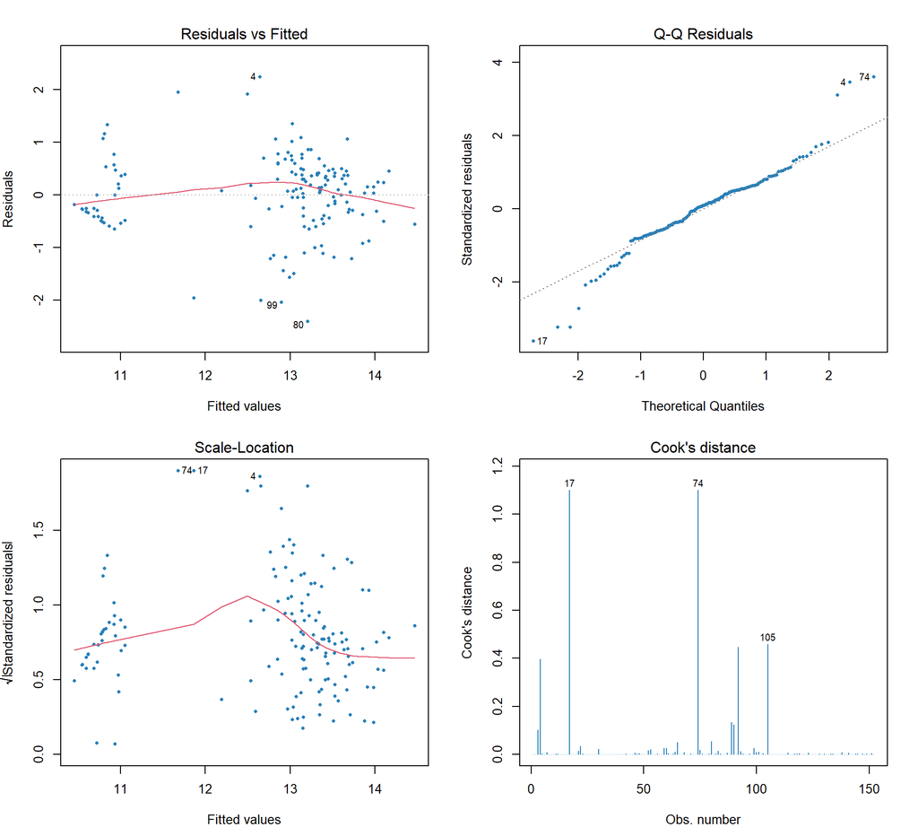

```r
par(mfrow = c(2,2), mar = c(4,4,3,2))
plot(mod, which = 1:4, col = "#2980b9", pch = 16, cex = 0.6)
```

**Python**

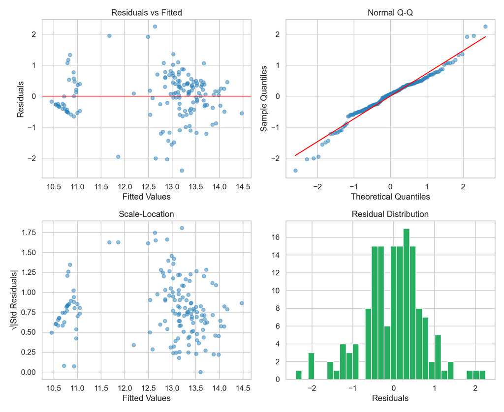

```python
fitted = mod_py.fittedvalues
resid  = mod_py.resid
std_resid = (resid - resid.mean()) / resid.std()

fig, axes = plt.subplots(2, 2, figsize=(11, 9))

# 1. Residuals vs Fitted
axes[0,0].scatter(fitted, resid, alpha=0.5, color="#2980b9", s=30)
axes[0,0].axhline(0, color="red", lw=1)
axes[0,0].set_xlabel("Fitted Values"); axes[0,0].set_ylabel("Residuals")
axes[0,0].set_title("Residuals vs Fitted")
# 2. Q-Q plot
from scipy.stats import probplot
pp = probplot(resid, dist="norm")
axes[0,1].scatter(pp[0][0], pp[0][1], alpha=0.5, color="#2980b9", s=30)
axes[0,1].plot(pp[0][0], pp[1][0]*pp[0][0]+pp[1][1], "r-")
axes[0,1].set_title("Normal Q-Q")
axes[0,1].set_xlabel("Theoretical Quantiles"); axes[0,1].set_ylabel("Sample Quantiles")
# 3. Scale-Location
axes[1,0].scatter(fitted, np.sqrt(np.abs(std_resid)), alpha=0.5, color="#2980b9", s=30)
axes[1,0].set_xlabel("Fitted Values"); axes[1,0].set_ylabel("√|Std Residuals|")
axes[1,0].set_title("Scale-Location")
# 4. Residuals histogram
axes[1,1].hist(resid, bins=30, color="#27ae60", edgecolor="white")
axes[1,1].set_title("Residual Distribution")
axes[1,1].set_xlabel("Residuals")
plt.tight_layout()
plt.savefig("diagnostics.png", dpi=150, bbox_inches="tight")
plt.show()
```